# Biology 708, McMaster University

# Data management and cleaning

Jonathan Dushoff, Ben Bolker

## Goals

- Introduce some principles of data management
- Introduce some practical, modern tools
- Show some examples

## Data analysis

Data must be:

- Organized
- Cleaned
- Manipulated
- Analyzed

The first three often take the most time, and this is often because researchers undervalue them.

There’s never time to do it right … but there’s always time to do it over!

## Structured tools for dealing with data

- dplyr
- tidyr
- readr

```r
## library(tidyverse)
library(dplyr)
library(tidyr)
library(readr)
```

## A sample data set

```r
villageTable <- read_csv("../data/village.csv")
```

## A sample data set

```r
summary(villageTable)
```

```
##         area        village             grid          fup
##  Length   :180   Min.   :  1.0   Length   :180   Min.   : 1.000
##  N.unique :  7   1st Qu.:211.2   N.unique : 50   1st Qu.: 3.000
##  N.blank  :  0   Median :362.5   N.blank  :  0   Median : 6.000
##  Min.nchar:  1   Mean   :402.0   Min.nchar:  2   Mean   : 6.217
##  Max.nchar:  7   3rd Qu.:565.2   Max.nchar:  3   3rd Qu.: 7.000
##                  Max.   :967.0   NAs      :  1   Max.   :92.000
##        vname             vu         grouped1         grouped2
##  Length   :180   Length   :180   Min.   :  0.00   Min.   : 0.0000
##  N.unique :178   N.unique : 22   1st Qu.:  0.00   1st Qu.: 0.0000
##  N.blank  :  0   N.blank  :  0   Median : 24.50   Median : 0.0000
##  Min.nchar:  4   Min.nchar:  3   Mean   : 37.06   Mean   : 0.7833
##  Max.nchar: 17   Max.nchar:  7   3rd Qu.: 52.25   3rd Qu.: 1.0000
##                                  Max.   :550.00   Max.   :10.0000
##    scattered1       scattered2        population
##  Min.   :  0.00   Min.   :0.00000   Min.   :   0.0
##  1st Qu.:  0.00   1st Qu.:0.00000   1st Qu.: 124.0
##  Median :  6.00   Median :0.00000   Median : 222.0
##  Mean   : 14.29   Mean   :0.01111   Mean   : 287.1
##  3rd Qu.: 22.00   3rd Qu.:0.00000   3rd Qu.: 375.0
##  Max.   :117.00   Max.   :1.00000   Max.   :2556.0
```

## A sample data set

```r
summary(villageTable |> mutate_if(is.character, as.factor))
```

```
##       area       village           grid          fup
##  A1     : 8   Min.   :  1.0   4C     :  7   Min.   : 1.000
##  A2     :62   1st Qu.:211.2   7C     :  7   1st Qu.: 3.000
##  B      :85   Median :362.5   8E     :  7   Median : 6.000
##  Babura : 1   Mean   :402.0   4B     :  6   Mean   : 6.217
##  Banzoma: 5   3rd Qu.:565.2   4D     :  6   3rd Qu.: 7.000
##  C      : 5   Max.   :967.0   (Other):146   Max.   :92.000
##  Ringim :14                   NAs    :  1
##             vname           vu        grouped1         grouped2
##  Daurawa       :  2   Kar    :26   Min.   :  0.00   Min.   : 0.0000
##  Sabon Gari    :  2   Dok    :21   1st Qu.:  0.00   1st Qu.: 0.0000
##  Adinis Fulanin:  1   Kit    :18   Median : 24.50   Median : 0.0000
##  Aduwa         :  1   Aju    :13   Mean   : 37.06   Mean   : 0.7833
##  Ajura         :  1   Gar    :13   3rd Qu.: 52.25   3rd Qu.: 1.0000
##  Anju          :  1   Sug    :13   Max.   :550.00   Max.   :10.0000
##  (Other)       :172   (Other):76
##    scattered1       scattered2        population
##  Min.   :  0.00   Min.   :0.00000   Min.   :   0.0
##  1st Qu.:  0.00   1st Qu.:0.00000   1st Qu.: 124.0
##  Median :  6.00   Median :0.00000   Median : 222.0
##  Mean   : 14.29   Mean   :0.01111   Mean   : 287.1
##  3rd Qu.: 22.00   3rd Qu.:0.00000   3rd Qu.: 375.0
##  Max.   :117.00   Max.   :1.00000   Max.   :2556.0
##
```

## A sample data set

```r
parasiteTable <- read_csv("../data/parademo.csv")
```

## A sample data set

```r
(parasiteTable |> mutate(across(where(is.character), as.factor))
    |> summary()
)
```

```
##        id           village         compound       survey          person
##  Min.   :    1   Min.   : 51.0   Min.   :  1   Min.   : 1.00   Min.   : 1.000
##  1st Qu.: 2671   1st Qu.:202.0   1st Qu.: 40   1st Qu.: 6.00   1st Qu.: 2.000
##  Median : 6186   Median :220.0   Median :205   Median :10.00   Median : 5.000
##  Mean   : 5980   Mean   :337.3   Mean   :176   Mean   :10.61   Mean   : 6.745
##  3rd Qu.: 8993   3rd Qu.:552.0   3rd Qu.:249   3rd Qu.:15.00   3rd Qu.: 9.000
##  Max.   :12849   Max.   :806.0   Max.   :949   Max.   :23.00   Max.   :99.000
##
##       sch             _add           tribe              hght
##  Min.   :0.000   Min.   :1.000   Min.   :0.00000   Min.   :  0.00
##  1st Qu.:1.000   1st Qu.:2.000   1st Qu.:0.00000   1st Qu.:  0.00
##  Median :1.000   Median :2.000   Median :0.00000   Median :  0.00
##  Mean   :1.189   Mean   :1.906   Mean   :0.08756   Mean   : 15.33
##  3rd Qu.:1.000   3rd Qu.:2.000   3rd Qu.:0.00000   3rd Qu.:  0.00
##  Max.   :5.000   Max.   :2.000   Max.   :3.00000   Max.   :985.00
##
##      sleep             dist               baby           alive
##  Min.   :0.0000   Min.   :0.00e+00   Min.   :0.000   Min.   :0.000000
##  1st Qu.:1.0000   1st Qu.:0.00e+00   1st Qu.:2.000   1st Qu.:0.000000
##  Median :1.0000   Median :0.00e+00   Median :2.000   Median :0.000000
##  Mean   :0.7863   Mean   :7.96e-05   Mean   :1.714   Mean   :0.005442
##  3rd Qu.:1.0000   3rd Qu.:0.00e+00   3rd Qu.:2.000   3rd Qu.:0.000000
##  Max.   :2.0000   Max.   :2.00e+00   Max.   :2.000   Max.   :2.000000
##
##     datecoll               coll               sliden            car1
##  Min.   :1970-10-26   Min.   :0.000e+00   Min.   :     0   Min.   :0.000
##  1st Qu.:1971-12-01   1st Qu.:1.000e+00   1st Qu.: 14967   1st Qu.:1.000
##  Median :1972-10-11   Median :1.000e+00   Median : 47182   Median :3.000
##  Mean   :1972-11-26   Mean   :1.384e+02   Mean   : 49504   Mean   :2.263
##  3rd Qu.:1973-08-29   3rd Qu.:1.000e+00   3rd Qu.: 81473   3rd Qu.:3.000
##  Max.   :1976-12-10   Max.   :1.900e+07   Max.   :117927   Max.   :3.000
##  NAs    :7
##      ncar1               car2           ncar2               filt
##  Min.   :    0.00   Min.   :0.000   Min.   :   0.000   Min.   :0.000
##  1st Qu.:    0.00   1st Qu.:1.000   1st Qu.:   0.000   1st Qu.:1.000
##  Median :    0.00   Median :3.000   Median :   0.000   Median :3.000
##  Mean   :   85.08   Mean   :2.298   Mean   :   1.888   Mean   :2.279
##  3rd Qu.:    0.00   3rd Qu.:3.000   3rd Qu.:   0.000   3rd Qu.:3.000
##  Max.   :30000.00   Max.   :3.000   Max.   :4200.000   Max.   :3.000
##
```

[output cut: 25 more lines]

```
##  Min.   :0.00000   Min.   :0.00000   Min.   :0.000000   Min.   :  0.00
##  1st Qu.:0.00000   1st Qu.:0.00000   1st Qu.:0.000000   1st Qu.:  0.00
##  Median :0.00000   Median :0.00000   Median :0.000000   Median :  0.00
##  Mean   :0.08759   Mean   :0.09235   Mean   :0.009935   Mean   : 16.38
##  3rd Qu.:0.00000   3rd Qu.:0.00000   3rd Qu.:0.000000   3rd Qu.:  3.00
##  Max.   :1.00000   Max.   :1.00000   Max.   :1.000000   Max.   :449.00
##
##      smove              agec
##  Min.   :0.00000   Min.   :0.00000
##  1st Qu.:0.00000   1st Qu.:0.00000
##  Median :0.00000   Median :0.00000
##  Mean   :0.00657   Mean   :0.00419
##  3rd Qu.:0.00000   3rd Qu.:0.00000
##  Max.   :1.00000   Max.   :7.00000
##
```

## Entering, maintaining and using data

- These are different functions, and often call for different ways of formatting data
- This is why we have computers

## Data use

- Scanning for patterns and problems
- Making tables for publication
- Making data frames for statistical analysis

## Data maintenance

- Your database is
  - a logical construct
    - The core of the data that we maintain and validate
  - maybe also a software construct
    - If you are using a database program
- Data in the database is:
  - Non-redundant
  - Relational
  - Often in a “long” format (to signal values that are comparable)

## Redundancy

You don’t want any redundancy in your database (although you might for entry or analysis)

- Removing redundancies is a great way to check data integrity
- Non-redundant information can be updated conveniently
  - and without introducing new errors
  - and without introducing inconsistencies

## Example

```r
head(parasiteTable)
```

```
## # A tibble: 6 × 39
##      id village compound survey person   sch `_add` tribe  hght sleep  dist
##   <dbl>   <dbl>    <dbl>  <dbl>  <dbl> <dbl>  <dbl> <dbl> <dbl> <dbl> <dbl>
## 1     1     801      401      1      1     1      1     1     0     1     0
## 2     1     801      401      2      1     1      2     0     0     1     0
## 3     1     801      401      3      1     1      2     0     0     1     0
## 4     1     801      401      4      1     1      2     0     0     1     0
## 5     1     801      401      5      1     1      2     0     0     1     0
## 6     1     801      401      6      1     1      2     0     0     1     0
## # ℹ 28 more variables: baby <dbl>, alive <dbl>, datecoll <date>, coll <dbl>,
## #   sliden <dbl>, car1 <dbl>, ncar1 <dbl>, car2 <dbl>, ncar2 <dbl>, filt <dbl>,
## #   nfilt <dbl>, fever <dbl>, datep <date>, micro <dbl>, dateexam <date>,
## #   slide <dbl>, exam <dbl>, pfa <dbl>, pfg <dbl>, pm <dbl>, po <dbl>,
## #   ppfa <dbl>, ppfg <dbl>, ppm <dbl>, ppo <dbl>, pf <dbl>, smove <dbl>,
## #   agec <dbl>
```

## Tidy data

- No redundancy
- Break data into separate tables following the logic of the data
- Clear “keys” to describe the information in each row
  - Non-redundant, unique identifiers
  - Village table has village (number) as the key
  - Measurement table has id, survey as the key’

## Relational

Break data into logical tables

- Information at the level where it belongs:
  - Sampling event
  - Individual
  - Household
  - Village
  - Village group
- Keys link diferent tables
  - The gender, height, birthdate fields from the Individual table can be linked to the Event table when needed

## Tidy example

```r
print(sim)
```

```
## # A tibble: 1,001 × 4
##     time       S     I       R
##    <dbl>   <dbl> <dbl>   <dbl>
##  1   0   390000   100  389900
##  2   0.1 389991   108  389901
##  3   0.2 389981.  117. 389902.
##  4   0.3 389971.  126. 389903.
##  5   0.4 389959.  136. 389905.
##  6   0.5 389947.  147. 389906.
##  7   0.6 389934.  159. 389907.
##  8   0.7 389920.  171. 389909.
##  9   0.8 389904.  185. 389911.
## 10   0.9 389888.  200. 389912.
## # ℹ 991 more rows
```

## Long data is often tidier

- Use long structure to mark things that are comparable, or have the same units
- We often use `pivot_longer` to make things tidier

```r
longsim <- pivot_longer(sim, cols=!time, names_to="class", values_to="people")
print(longsim)
```

```
## # A tibble: 3,003 × 3
##     time class  people
##    <dbl> <chr>   <dbl>
##  1   0   S     390000
##  2   0   I        100
##  3   0   R     389900
##  4   0.1 S     389991
##  5   0.1 I        108
##  6   0.1 R     389901
##  7   0.2 S     389981.
##  8   0.2 I        117.
##  9   0.2 R     389902.
## 10   0.3 S     389971.
## # ℹ 2,993 more rows
```

## Wide data is often more readable

```r
print(pivot_wider(longsim, names_from=class, values_from=people))
```

```
## # A tibble: 1,001 × 4
##     time       S     I       R
##    <dbl>   <dbl> <dbl>   <dbl>
##  1   0   390000   100  389900
##  2   0.1 389991   108  389901
##  3   0.2 389981.  117. 389902.
##  4   0.3 389971.  126. 389903.
##  5   0.4 389959.  136. 389905.
##  6   0.5 389947.  147. 389906.
##  7   0.6 389934.  159. 389907.
##  8   0.7 389920.  171. 389909.
##  9   0.8 389904.  185. 389911.
## 10   0.9 389888.  200. 389912.
## # ℹ 991 more rows
```

Also necessary for many analyses

## Flow

- Put input data into a tidy, relational form
  - Clean on the way
  - This is your database, whether you use database software or not
- Clean, maintain and merge data in the database
- Export files for analysis, presentation, etc.
  - You may wind up rebuilding files like the ones you started with
  - They are now quality-checked, and may also be easier to update

# Importing

## Summarize

- Check that numbers are numbers, dates are dates, etc.

```r
villageTable <- (villageTable
    %>% mutate(village=as.factor(village))
)
summary(villageTable)
```

```
##         area        village           grid          fup               vname
##  Length   :180   1      :  1   Length   :180   Min.   : 1.000   Length   :180
##  N.unique :  7   2      :  1   N.unique : 50   1st Qu.: 3.000   N.unique :178
##  N.blank  :  0   3      :  1   N.blank  :  0   Median : 6.000   N.blank  :  0
##  Min.nchar:  1   4      :  1   Min.nchar:  2   Mean   : 6.217   Min.nchar:  4
##  Max.nchar:  7   5      :  1   Max.nchar:  3   3rd Qu.: 7.000   Max.nchar: 17
##                  6      :  1   NAs      :  1   Max.   :92.000
##                  (Other):174
##          vu         grouped1         grouped2         scattered1
##  Length   :180   Min.   :  0.00   Min.   : 0.0000   Min.   :  0.00
##  N.unique : 22   1st Qu.:  0.00   1st Qu.: 0.0000   1st Qu.:  0.00
##  N.blank  :  0   Median : 24.50   Median : 0.0000   Median :  6.00
##  Min.nchar:  3   Mean   : 37.06   Mean   : 0.7833   Mean   : 14.29
##  Max.nchar:  7   3rd Qu.: 52.25   3rd Qu.: 1.0000   3rd Qu.: 22.00
##                  Max.   :550.00   Max.   :10.0000   Max.   :117.00
##
##    scattered2        population
##  Min.   :0.00000   Min.   :   0.0
##  1st Qu.:0.00000   1st Qu.: 124.0
##  Median :0.00000   Median : 222.0
##  Mean   :0.01111   Mean   : 287.1
##  3rd Qu.:0.00000   3rd Qu.: 375.0
##  Max.   :1.00000   Max.   :2556.0
##
```

## List

- Make lists of what occurs with what (and how many times)

```r
print(villageTable
    %>% group_by(vname, vu)
    %>% summarize(count = n())
)
```

```
## `summarise()` has regrouped the output.
## ℹ Summaries were computed grouped by vname and vu.
## ℹ Output is grouped by vname.
## ℹ Use `summarise(.groups = "drop_last")` to silence this message.
## ℹ Use `summarise(.by = c(vname, vu))` for per-operation grouping
##   (`?dplyr::dplyr_by`) instead.
```

```
## # A tibble: 180 × 3
## # Groups:   vname [178]
##    vname           vu    count
##    <chr>           <chr> <int>
##  1 Adinis Fulanin  Kar       1
##  2 Aduwa           Aju       1
##  3 Ajura           Aju       1
##  4 Anju            Dok       1
##  5 Arindi          Sug       1
##  6 Asayaya         Kit       1
##  7 Ba'wa           Dok       1
##  8 Bakan Sabara    Kar       1
##  9 Bakan Sabara II Kar       1
## 10 Balalashi       Dok       1
## # ℹ 170 more rows
```

## Better counting

```r
print(villageTable
    %>% count(vname, vu, name="count")
)
```

```
## # A tibble: 180 × 3
##    vname           vu    count
##    <chr>           <chr> <int>
##  1 Adinis Fulanin  Kar       1
##  2 Aduwa           Aju       1
##  3 Ajura           Aju       1
##  4 Anju            Dok       1
##  5 Arindi          Sug       1
##  6 Asayaya         Kit       1
##  7 Ba'wa           Dok       1
##  8 Bakan Sabara    Kar       1
##  9 Bakan Sabara II Kar       1
## 10 Balalashi       Dok       1
## # ℹ 170 more rows
```

## …

- The computer is your friend

```r
print(villageTable
    %>% count(vname, vu, name="count")
    %>% filter(count>1)
)
```

```
## # A tibble: 0 × 3
## # ℹ 3 variables: vname <chr>, vu <chr>, count <int>
```

## …

- and you always want to check yourself

```r
print(villageTable
    %>% count(vname, name="count")
    %>% filter(count>1)
)
```

```
## # A tibble: 2 × 2
##   vname      count
##   <chr>      <int>
## 1 Daurawa        2
## 2 Sabon Gari     2
```

## Making relational tables

If we had data like the `parasiteTable`, we would want to break it into

- A table at the level of people
- A table at the level of sampling events
- A table at the level of measurements

This process leads to improved clarity, **and improved cleaning**

## Parasite table

```r
print(parasiteTable
    %>% count(id, village, compound, name="count")
)
```

```
## # A tibble: 13,656 × 4
##       id village compound count
##    <dbl>   <dbl>    <dbl> <int>
##  1     1     801      401    16
##  2     2     801      401    16
##  3     3     801      401    16
##  4     4     801      401    16
##  5     5     801      401    16
##  6     6     801      401    16
##  7     7     801      401    12
##  8     8     801      401    11
##  9     9     801      401    15
## 10     9     801      417     1
## # ℹ 13,646 more rows
```

## Parasite table

```r
print(parasiteTable
    %>% count(id, village, compound, name="count")
    %>% count(id, name="count")
    %>% filter(count>1)
    %>% arrange(desc(count))
)
```

```
## # A tibble: 756 × 2
##       id count
##    <dbl> <int>
##  1  6571     4
##  2  6572     4
##  3  6573     4
##  4  6574     4
##  5  6575     4
##  6  6576     4
##  7  6577     4
##  8  6578     4
##  9    41     3
## 10  1081     3
## # ℹ 746 more rows
```

## Explore ranges

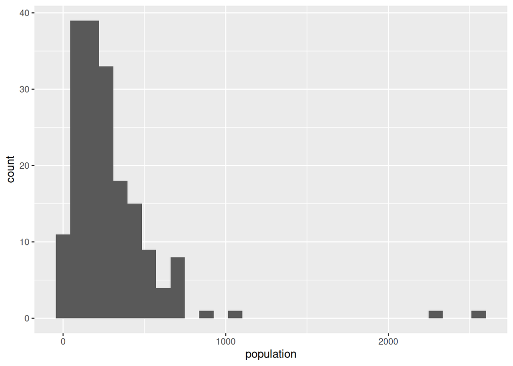

```r
library(ggplot2)
print(ggplot(villageTable, aes(x=population))
    + geom_histogram()
)
```

# Correction tables

## Mistakes

Let’s say you find an obvious error in your data

```
##   country continent count
## 1   Kenya    Africa    23
## 2  Uganda    Africa    31
## 3  Ungada    Africa     1
## 4 Vietnam      Asia    16
```

How should you fix it?

## A table

A table:

- respects the original data
- records your decision
- is transparent to yourself and others
- **fixes the mistake again, if it happens again**

```
##   country patchcountry
## 1  Ungada       Uganda
```

- Make a csv with an editor or spreadsheet program

## Patching

- Fix the problem as far “upstream” as possible
- Not the count table (as I’m doing here)

```r
patchTab <- (ctab
    %>% left_join(cortab)
)
print(patchTab)
```

```
##   country continent count patchcountry
## 1   Kenya    Africa    23         <NA>
## 2  Uganda    Africa    31         <NA>
## 3  Ungada    Africa     1       Uganda
## 4 Vietnam      Asia    16         <NA>
```

## …

```
##   country continent count patchcountry
## 1   Kenya    Africa    23         <NA>
## 2  Uganda    Africa    31         <NA>
## 3  Ungada    Africa     1       Uganda
## 4 Vietnam      Asia    16         <NA>
```

## NA logic is scary

NA means “Something I don’t know”. You don’t get the answers you expect if you compare things to NA:

```r
"Jonathan" == NA
```

```
## [1] NA
```

## Finish the patch, being careful

```r
ctab <- (patchTab
    %>% mutate(country=ifelse(is.na(patchcountry), country, patchcountry))
    %>% select(-patchcountry)
)
print(ctab)
```

```
##   country continent count
## 1   Kenya    Africa    23
## 2  Uganda    Africa    31
## 3  Uganda    Africa     1
## 4 Vietnam      Asia    16
```

## Be careful-er

```r
ctab <- (patchTab
    %>% mutate(country=ifelse(is.na(patchcountry), country,
        as.character(patchcountry)))
    %>% select(-patchcountry)
)
print(ctab)
```

```
##   country continent count
## 1   Kenya    Africa    23
## 2  Uganda    Africa    31
## 3  Uganda    Africa     1
## 4 Vietnam      Asia    16
```

- Never be afraid to break pipes up or put them back together.

## Factors

- Factors can be useful, but they’re also often weird
- Be aware of this as a possible problem
- The more you use tools from the tidy family, the less factor weirdness you will encounter

## Dictionary tables

- You might want to summarize a factor variable into categories that you define
- In this case you could use a similar table (Ungada $\to$ Uganda), but different logic
  - You only want to keep the new version
  - … and check for cases where the original is not matched

## Making dictionaries

Print out all the codes for a particular variable, and see what you think of them

```r
print(religTab
    %>% select(code)
    %>% distinct()
)
```

```
## # A tibble: 62 × 1
##    code
##    <chr>
##  1 Catholic
##  2 Orthodox
##  3 Roman catholic
##  4 Adventist
##  5 Anglican
##  6 Anglican Church
##  7 Apostolic Sect
##  8 Aventist
##  9 CCAP
## 10 Charismatic
## # ℹ 52 more rows
```

## Coders can be funny

```r
print(religTab
    %>% select(code)
    %>% distinct()
    %>% filter(grepl("^M", code))
)
```

```
## # A tibble: 9 × 1
##   code
##   <chr>
## 1 Methodist
## 2 Moslem
## 3 Muslem
## 4 Mulsim
## 5 Muslim
## 6 Muslum
## 7 Musualmane
## 8 Mana
## 9 Mungu
```

## Build a dictionary

You should start by editing the output from your previous step

```r
print(religTab)
```

```
## # A tibble: 62 × 2
##    category          code
##    <chr>             <chr>
##  1 Catholic/Orthodox Catholic
##  2 Catholic/Orthodox Orthodox
##  3 Catholic/Orthodox Roman catholic
##  4 Christian         Adventist
##  5 Christian         Anglican
##  6 Christian         Anglican Church
##  7 Christian         Apostolic Sect
##  8 Christian         Aventist
##  9 Christian         CCAP
## 10 Christian         Charismatic
## # ℹ 52 more rows
```

## Using a dictionary

Start the same way as before.

```
##         person       religion
## 1 Ntombikayise         Mulsim
## 2    Gao Zhong       Anglican
## 3      Mafalda         Angler
## 4         Bill Roman catholic
```

```r
patchTab <- (churchTab
    %>% left_join(religTab, by=c("religion"="code"))
) %>% print()
```

```
##         person       religion          category
## 1 Ntombikayise         Mulsim            Muslim
## 2    Gao Zhong       Anglican         Christian
## 3      Mafalda         Angler              <NA>
## 4         Bill Roman catholic Catholic/Orthodox
```

### …

```
##         person       religion          category
## 1 Ntombikayise         Mulsim            Muslim
## 2    Gao Zhong       Anglican         Christian
## 3      Mafalda         Angler              <NA>
## 4         Bill Roman catholic Catholic/Orthodox
```

## Dictionary replacement

But use different logic for replacement

```r
catTab <- (patchTab
    %>% mutate(religion=category)
    %>% select(-category)
) %>% print()
```

```
##         person          religion
## 1 Ntombikayise            Muslim
## 2    Gao Zhong         Christian
## 3      Mafalda              <NA>
## 4         Bill Catholic/Orthodox
```

## Play with your data

- Don’t touch the original data
- Make scripts and make sure that they are replicable
- Don’t be afraid to play, experiment, probe
- You want to like your data-manipulation tools, and get your data as clean as possible

## Summary

- Let the computer serve you
  - Input in the form that you want to input
  - Manage in the tidy form that is efficient and logical
  - Output in the way you want to output
- Be aggressive about exploring, questioning and cleaning